# Data exploration

```python
from IPython.display import HTML

HTML('''<script>
code_show=true;
function code_toggle() {
 if (code_show){
 $('div.input').hide();
 } else {
 $('div.input').show();
 }
 code_show = !code_show
}
$( document ).ready(code_toggle);
</script>
<form action="javascript:code_toggle()"><input type="submit" value="Click here to toggle on/off the raw code."></form>''')
```

```python
import pandas as pd
import numpy as np
import pickle

import seaborn as sns
import matplotlib.pyplot as plt
import matplotlib

%matplotlib inline
```

```python
df = pd.read_pickle('data.pkl')
df['is_subscriber'] =  df.app_subscriberid.map(lambda x: 0 if 'none' in x else 1)
print('Number of subscribers = ', str((sum(df['is_subscriber'])/len(df))*100)+'%')
```

```
Number of subscribers =  12.71497301389601%
```

```python
(sum(df.click)/len(df))*100
```

```
0.5871003980755611
```

```python
print('Number of observations :     ', 204735)
print('Number of available features:', 67)
```

```
Number of observations :      204735
Number of available features: 67
```

```python
#list_columns = [] #not shown
for col in df.columns:
    if col in list_columns:
        df[col] = df[col].apply(str)
```

# Data exploration

```python
df_num = df.select_dtypes(include = ['float64', 'int64'])
```

## General distribution

```python
df_num['whex'] = df['ws']+df['hs']+df['exchange']
df_num['gender'] = df.gender
df_num['click'] = df.click
df_num['responseid'] = df.responseid
df_num['is_subscriber'] = df.is_subscriber
```

### Using all data (impressions)

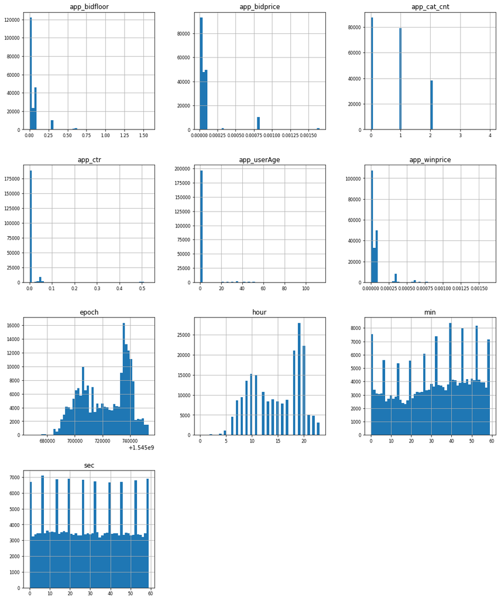

```python
df_num.hist(figsize=(16, 20), bins=50, xlabelsize=8, ylabelsize=8);
```

#### Distribution of Age (excluding Age=0)

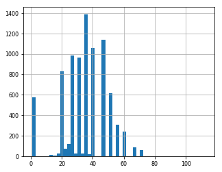

```python
df_num[df_num.age>0]['age'].hist(figsize=(5, 4), bins=50, xlabelsize=8, ylabelsize=8)
```

- Most users are from 20-45

#### Breakdown by Age and Gender

```
array([[<matplotlib.axes._subplots.AxesSubplot object at 0x7faa9109b630>,
      dtype=object)
```

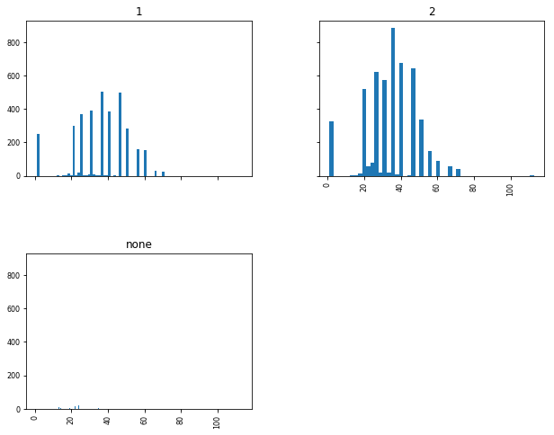

```python
df_num[df_num.age>0][['gender','age']].hist(column='age',
                            by='gender',figsize=(10, 8), bins=50, xlabelsize=8, ylabelsize=8,
                            sharex=True, sharey=True)
```

- 1=Male, 2=Female
- Most of the ads were displayed on Females, 20-45 yrs old

### Using all data (clicks)

```
array([[<matplotlib.axes._subplots.AxesSubplot object at 0x7faa8a6bb860>,
      dtype=object)
```

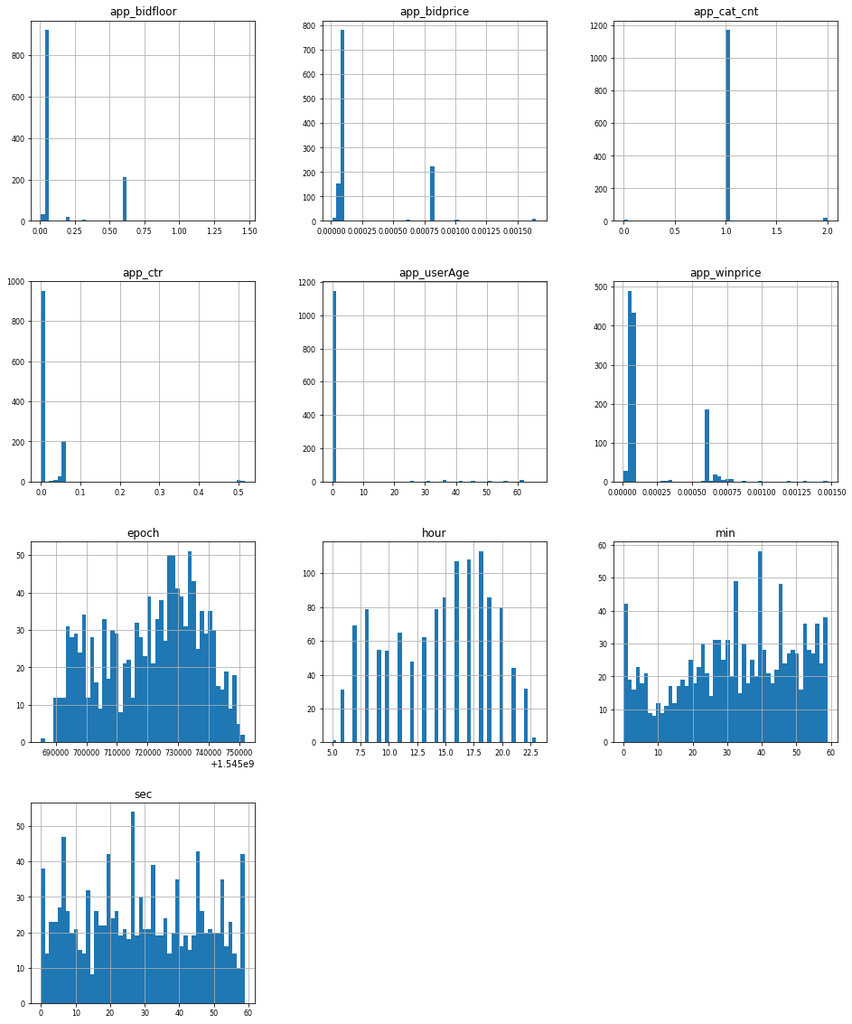

```python
df_num[df_num.click=='1'].hist(figsize=(16, 20), bins=50, xlabelsize=8, ylabelsize=8)
```

#### Distribution of Age (excluding Age=0)

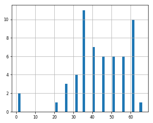

```python
df_num[(df_num.age>0) & (df_num.click=='1')]['age'].hist(figsize=(5, 4), bins=50, xlabelsize=8, ylabelsize=8)
```

- As expected, most of those who clicked are from the older age bracket (> 35 years old)

#### Breakdown by Age and Gender

```
array([<matplotlib.axes._subplots.AxesSubplot object at 0x7faa88e0dcc0>,
      dtype=object)
```

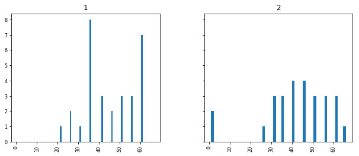

```python
df_num[(df_num.age>0)&(df_num.click=='1')][['gender','age']].hist(column='age',
                            by='gender',figsize=(10, 4), bins=50, xlabelsize=8, ylabelsize=8,
                            sharex=True, sharey=True)
```

- Most of those who clicked are Males, >35 yrs old. Possibly because a few of the ads on this particular date were about gaming
- There are very young (<10 yrs old) Females who clicked the ads

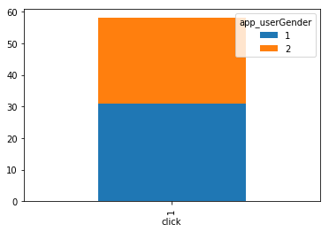

```python
df_num[(df_num.click=='1') & (df_num.gender!='none')].groupby(df_num.click)['gender']\
    .value_counts()\
    .unstack(1)\
    .plot(kind='bar', stacked=True)
```

- The barplot above just shows that there seems to be not much difference between Gender in terms of the number of clicks they generate

### Comparing clicks of subscribers vs non-subscribers

```python
ct =  pd.crosstab(df_num.is_subscriber,df_num.click).reset_index()
ct['ctr_pcnt'] = (ct['1']/(ct['0']+ct['1']))*100
ct
```

| click | is_subscriber | 0 | 1 | ctr_pcnt |
| --- | --- | --- | --- | --- |
| 0 | 0 | 177739 | 964 | 0.539443 |
| 1 | 1 | 25794 | 238 | 0.914259 |

```python
print('% of those who are subscribers and did not click: ',(964/(177739+964))*100)
print('% of those who are subscribers and clicked:       ', (238/(25794+238))*100)
```

[output not shown]

```python
print('% of those who clicked among non-subscribers: ',(25794/(177739+25794))*100)
print('% of those who clicked among subscribers:     ', (238/(964+238))*100)
```

[output not shown]

## Diving down to the most common creative ad sizes

### 320|480|ex1

```python
idx = 0
print(common_whex[idx])
#df_num[df_num.whex==common_whex[idx]].hist(figsize=(16, 20), bins=50, xlabelsize=8, ylabelsize=8)
```

#### Breakdown by Age and Gender

```
array([<matplotlib.axes._subplots.AxesSubplot object at 0x7faa95099cf8>,
      dtype=object)
```

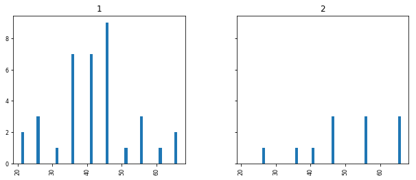

```python
df_num[(df_num.whex==common_whex[idx]) & (df_num.age>0)][['gender','age']].hist(column='age',
            by='gender',figsize=(10, 4), bins=50, xlabelsize=8,
            ylabelsize=8, sharex=True, sharey=True)
```

- Most of the ads were displayed on Males, 35-45yrs old

#### Click grouped by Gender

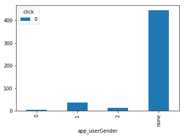

```python
df_num[(df_num.whex==common_whex[idx])].groupby(df_num.gender)['click']\
    .value_counts()\
    .unstack(1)\
    .plot(kind='bar', stacked=True)
```

- Nobody clicked for this ad size in echange 1

### 300|250|ex1

```python
idx = 2
print(common_whex[idx])
#df_num[df_num.whex==common_whex[idx]].hist(figsize=(16, 20), bins=50, xlabelsize=8, ylabelsize=8)
```

```
array([<matplotlib.axes._subplots.AxesSubplot object at 0x7faa9234e8d0>,
      dtype=object)
```

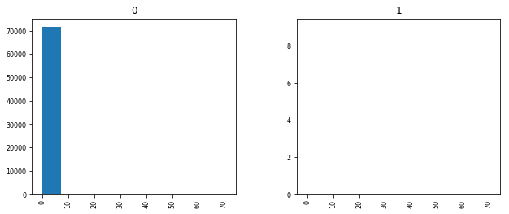

```python
df_num[df_num.whex==common_whex[idx]][['age','click']].hist(column='age',
                            by='click',figsize=(10, 4), bins=10, xlabelsize=8, ylabelsize=8,
                            sharex=True)#, sharey=True)
```

#### Breakdown by Age and Gender

```
array([<matplotlib.axes._subplots.AxesSubplot object at 0x7faa91ff9a90>,
      dtype=object)
```

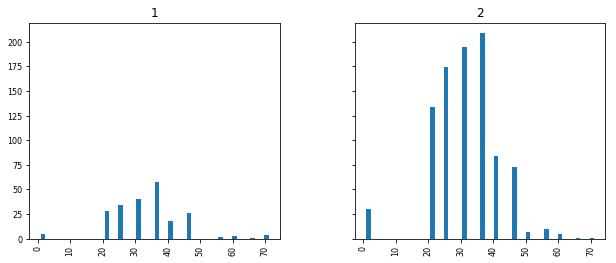

```python
df_num[(df_num.whex==common_whex[idx]) & (df_num.age>0)][['gender','age']].hist(column='age',
            by='gender',figsize=(10, 4), bins=50, xlabelsize=8,
            ylabelsize=8, sharex=True, sharey=True)
```

- Interestingly, for this ad size in exchange 1, most of the ads were displayed for Females 20-35 yrs old.

### 320|480|ex2

```python
idx = 3
print(common_whex[idx])
#df_num[df_num.whex==common_whex[idx]].hist(figsize=(16, 20), bins=50, xlabelsize=8, ylabelsize=8)
```

#### Predicted CTR vs True CTR (within the day, by hour)

- This WHEX has more click data than others

##### NOTE: we want the predicted CTR to have the same distribution of the number of clicks across hour (x-xis:hour)

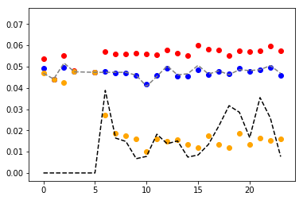

```python
ctr_avg = df_num[df_num.whex==common_whex[idx]][['hour','ctr']].groupby(['hour']).mean().reset_index()
ctr_max = df_num[df_num.whex==common_whex[idx]][['hour','ctr']].groupby(['hour']).max().reset_index()
ctr_min = df_num[df_num.whex==common_whex[idx]][['hour','ctr']].groupby(['hour']).min().reset_index()
ctr_median = df_num[df_num.whex==common_whex[idx]][['hour','ctr']].groupby(['hour']).median().reset_index()
plt.scatter(ctr_max['hour'],ctr_max['ctr'], color='red')
plt.scatter(ctr_max['hour'],ctr_avg['ctr'], color='blue')
plt.plot(ctr_max['hour'],ctr_median['ctr'], color='gray', linestyle='--')
plt.scatter(ctr_max['hour'],ctr_min['ctr'],color='orange')
plt.plot(win_click['hour'],win_click['true_ctr'],color='black', linestyle='--')
```

- The TRUE CTR is shown by the black dashed line, the Median predicted CTR is the gray dashed line
- x-axis is hour
- Comparing the two lines, our median predicted CTR is higher than the True CTR

#### Breakdown by Age and Gender (impressions)

```
array([<matplotlib.axes._subplots.AxesSubplot object at 0x7faa848d5278>,
      dtype=object)
```

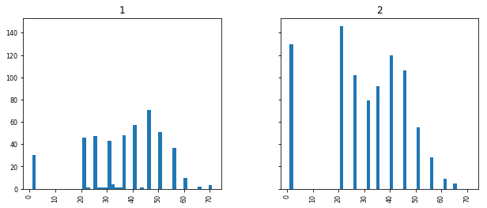

```python
df_num[(df_num.whex==common_whex[idx]) & (df_num.age>0)][['gender','age']].hist(column='age',
            by='gender',figsize=(10, 4), bins=50, xlabelsize=8,
            ylabelsize=8, sharex=True, sharey=True)
```

- Most of the ads were displayed on Females 20-45 yrs old. This is very different demographics compared to exchange 1 for the same creative ad size. Refer to 1.2.1.1. wherein most of the ads were displayed on Males, 35-45yrs old.

#### Breakdown by Age and Gender (clicks)

```
array([<matplotlib.axes._subplots.AxesSubplot object at 0x7faa942e5dd8>,
      dtype=object)
```

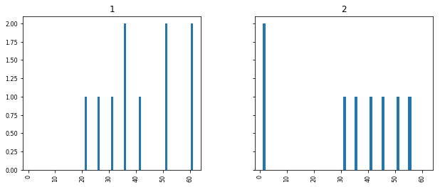

```python
df_num[(df_num.whex==common_whex[idx])&(df_num.age>0)&(df_num.click=='1')][['gender','age']].hist(column='age',
                            by='gender',figsize=(10, 4), bins=50, xlabelsize=8, ylabelsize=8,
                            sharex=True, sharey=True)
```

- Not much difference in Gender and Age among those who clicked
- This somehow shows that, regardless of creative ad size and user demographics, exchange 2 generates more clicks than exachange 1. If we want more clicks, we should really bid more on exchange 2 than exchange 1.

### 300|250|ex2

```python
idx = 5
print(common_whex[idx])
#df_num[df_num.whex==common_whex[idx]].hist(figsize=(16, 20), bins=50, xlabelsize=8, ylabelsize=8)
```

#### Breakdown by Age and Gender (impressions)

```
array([[<matplotlib.axes._subplots.AxesSubplot object at 0x7faa7d12d710>,
      dtype=object)
```

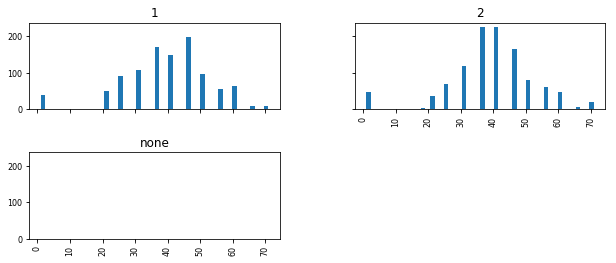

```python
df_num[(df_num.whex==common_whex[idx]) & (df_num.age>0)][['gender','age']].hist(column='age',
            by='gender',figsize=(10, 4), bins=50, xlabelsize=8,
            ylabelsize=8, sharex=True, sharey=True)
```

#### Breakdown by Age and Gender (clicks)

```
array([<matplotlib.axes._subplots.AxesSubplot object at 0x7faa7db29e80>,
      dtype=object)
```

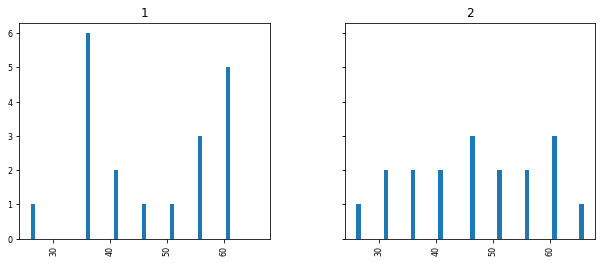

```python
df_num[(df_num.whex==common_whex[idx])&(df_num.age>0)&(df_num.click=='1')][['gender','age']].hist(column='age',
                            by='gender',figsize=(10, 4), bins=50, xlabelsize=8, ylabelsize=8,
                            sharex=True, sharey=True)
```

#### Predicted CTR vs True CTR

```python
ctr_avg = df_num[df_num.whex==common_whex[idx]][['hour','ctr']].groupby(['hour']).mean().reset_index()
ctr_max = df_num[df_num.whex==common_whex[idx]][['hour','ctr']].groupby(['hour']).max().reset_index()
ctr_min = df_num[df_num.whex==common_whex[idx]][['hour','ctr']].groupby(['hour']).min().reset_index()
ctr_median = df_num[df_num.whex==common_whex[idx]][['hour','ctr']].groupby(['hour']).median().reset_index()
plt.scatter(ctr_max['hour'],ctr_max['ctr'], color='red')
plt.scatter(ctr_max['hour'],ctr_avg['ctr'], color='blue')
plt.plot(ctr_max['hour'],ctr_median['ctr'], color='gray', linestyle='--')
plt.scatter(ctr_max['hour'],ctr_min['ctr'],color='orange')
plt.plot(win_click['hour'],win_click['true_ctr'],color='black', linestyle='--')
```

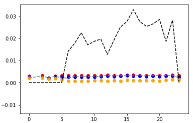

```python
from IPython.display import Image
Image(filename = "300_250.png", width=400, height=1000)
```

```
(0.0, 0.004)
```

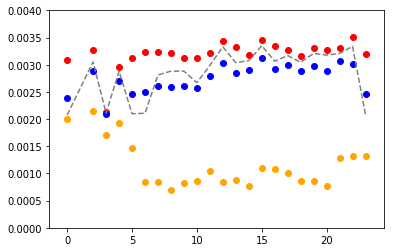

```python
plt.scatter(ctr_max['hour'],ctr_max['ctr'], color='red')
plt.scatter(ctr_max['hour'],ctr_avg['ctr'], color='blue')
plt.plot(ctr_max['hour'],ctr_median['ctr'], color='gray', linestyle='--')
plt.scatter(ctr_max['hour'],ctr_min['ctr'],color='orange')
plt.ylim(0.,0.004)
```

- For this WHEX, we are under-predicting the true CTR

# Correlation

```python
df_num_corr = df_num.corr()['winprice']
golden_features_list = df_num_corr[abs(df_num_corr) > 0.1].sort_values(ascending=False)
```

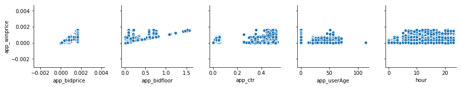

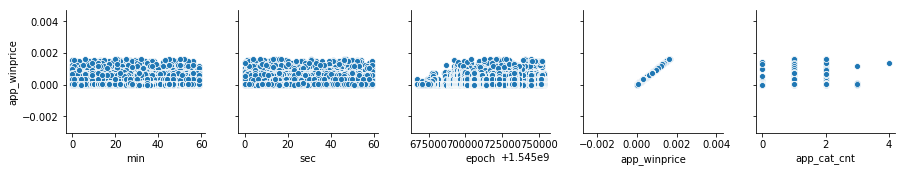

```python
for i in range(0, len(df_num.columns), 5):
    sns.pairplot(data=df_num,
                x_vars=df_num.columns[i:i+5],
                y_vars=['winprice'])
```

- Clearly, winprice is highly correlated with bidfloor

# Feature engineer

### Numeric values: Bucket into groups

```python
bin_hour = range(0, 23, 3)
df['hour_bucket'] = pd.cut(df.hour, bins=bin_hour)
df['hour_bucket'].value_counts()
```

```
(18, 21]    55100
(9, 12]     40864
(15, 18]    37699
(6, 9]      31420
(12, 15]    25640
(3, 6]       5862
(0, 3]        258
Name: hour_bucket, dtype: int64
```

```python
bin_min = range(0, df['min'].max(), 8)
df['min_bucket'] = pd.cut(df['min'], bins=bin_min)
df['min_bucket'].value_counts()
```

```
(48, 56]    32276
(40, 48]    31883
(32, 40]    29978
(24, 32]    27361
(0, 8]      24126
(16, 24]    22661
(8, 16]     21580
Name: min_bucket, dtype: int64
```

### Categories: Factorize into numeric

```python
df['whex'] = df['Ws'].apply(str) + df['Hs'].apply(str) + df.exchange
# Factorize the values
labels,levels = pd.factorize(df.click)
df.click = labels
```

```python
df_num = df.select_dtypes(include = ['float64', 'int64'])
df_cat_cols = list(set(df.columns) - set(df_num.columns))
df_cat = df[df_cat_cols]
```

# Grouping ad size by winprice

```python
from sklearn.decomposition import PCA
from sklearn.preprocessing import StandardScaler
```

```python
pca = PCA(n_components=2)
X = df[['app_Ws', 'app_Hs', 'app_winprice']]
scaler = StandardScaler().fit(X)
rescaledX = scaler.transform(X)
reduced_data = pca.fit_transform(rescaledX)
reduced_data.shape
```

## Principal components by winprice

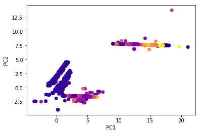

```python
col = 'winprice_bucket'
labels,levels = pd.factorize(df[col])
df[col+'_num'] = labels

plt.scatter(reduced_data[:,0], reduced_data[:,1], c=df.winprice_bucket_num, cmap = 'plasma')
plt.xlabel('PC1')
plt.ylabel('PC2')
plt.show()
```

## Width and Height by winprice

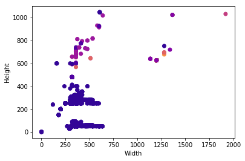

```python
plt.scatter(df.Ws, df.Hs, c=df.winprice_bucket_num,cmap = 'plasma')
plt.xlabel('Width')
plt.ylabel('Height')
plt.show()
```

## Width and Height by bidfloor

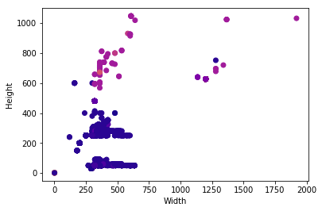

```python
col = 'bidfloor_bucket'
labels,levels = pd.factorize(df[col])
df[col+'_num'] = labels

plt.scatter(df.Ws, df.Hs, c=df.bidfloor_bucket_num,cmap = 'plasma')
plt.xlabel('Width')
plt.ylabel('Height')
plt.show()
```

- It is clear that the creative ad sizes can be grouped into two or three based on their win prices (or bidfloor)
- We can use this information if we want to group the creative ad sizes in a meaningful way

# Feature selection

```python
from sklearn.ensemble import RandomForestClassifier, RandomForestRegressor
from sklearn.tree import DecisionTreeClassifier,DecisionTreeRegressor, export_graphviz
from sklearn.model_selection import train_test_split
from sklearn.metrics import accuracy_score, mean_squared_error, roc_auc_score, roc_curve, classification_report

from IPython.display import display
from IPython.display import Image
%matplotlib inline

#imbalanced data
from imblearn.over_sampling import SMOTE

#Recursive Feature Elimination
from sklearn.feature_selection import RFE
from sklearn.linear_model import LogisticRegression

import statsmodels.api as sm
from sklearn.feature_selection import SelectFromModel
```

## All available features

### Imbalanced

```python
df_num_categ = pd.read_pickle('data2.pkl')
```

```python
X = df_num_categ
y = df['click']
```

```python
categories= [col for col in X.columns if 'num' in col] + ['is_subscriber']
X_categ = X[categories]
np.shape(X_categ)
```

```
(204735, 45)
```

```python
X_num = X.drop(categories, axis=1)
```

```python
for col in X_categ.columns:
    X_categ[col] =  X_categ[col].apply(str)
```

```python
dummies = []
for col in X_categ.columns:
    if len(set(X_categ[col])) > 2:
        dummies.append(col)
```

```python
X_dummies = pd.get_dummies(X_categ[dummies])
X_categ = X_categ.drop(dummies, axis=1)
np.shape(X_num), np.shape(X_categ), np.shape(X_dummies)
```

```
((204735, 5), (204735, 32), (204735, 2362))
```

```python
X_all = pd.concat([X_num, X_categ], axis=1)
X_all = pd.concat([X_all, X_dummies], axis=1)
np.shape(X_all)
```

```
(204735, 2399)
```

```python
X = X_all
y = df['click']
```

### 1. Tree

```python
X_train, X_test, y_train, y_test = train_test_split(
    X, y, test_size=0.3, random_state=0)

print('#Training data points: %d' % X_train.shape[0])
print('#Testing data points: %d' % X_test.shape[0])
print('Class labels:', np.unique(y))
```

```
#Training data points: 143314
#Testing data points: 61421
Class labels: ['0' '1']
```

```python
# criterion : impurity function
# max_depth : maximum depth of tree
# random_state : seed of random number generator
tree = DecisionTreeClassifier(criterion='entropy',
                              max_depth=3,
                              random_state=0)
tree.fit(X_train, y_train)
y_pred = tree.predict(X_test)
print('Misclassified samples: %d' % (y_test != y_pred).sum())
print('Accuracy (tree): %.2f' % ((y_test == y_pred).sum() / y_test.shape[0]))

# a more convenient way to evaluate a trained model is to use the sklearn.metrics
print('Accuracy (tree, sklearn): %.2f' % accuracy_score(y_test, y_pred))
```

```
Misclassified samples: 384
Accuracy (tree): 0.99
Accuracy (tree, sklearn): 0.99
```

```python
export_graphviz(tree, out_file='tree-all.dot',
                feature_names=X.columns.values)
```

dot -Tpng tree-all.dot -o fig-tree-all.png

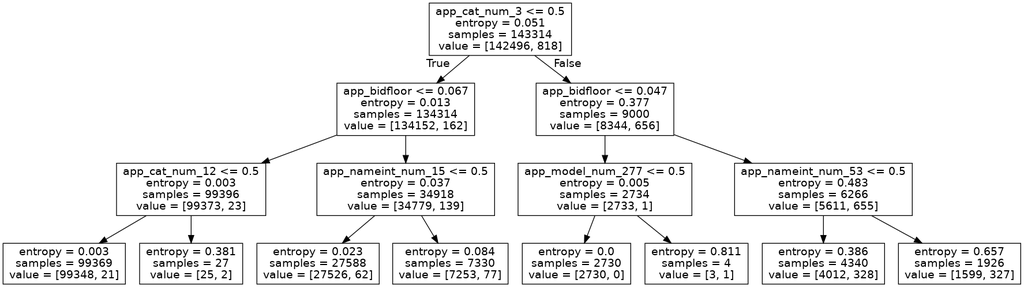

```python
Image(filename = "fig-tree-all.png", width=1000, height=1000)
```

```python
labels,levels = pd.factorize(df['cat'])
df['cat_labels'] = labels
cat_mapping = df[['cat_labels','cat']]
cat_mapping = cat_mapping.drop_duplicates()

cat_result = [3,12] #IAB19:Technology & Computing, IAB9-30: Video & Computer Games
for cat in cat_result:
    print(cat_mapping[cat_mapping.cat_labels == cat])
```

```
   app_cat_labels  app_cat
6               3  (IAB19)
     app_cat_labels    app_cat
293              12  (IAB9-30)
```

```python
labels,levels = pd.factorize(df['model'])
df['model_labels'] = labels
model_mapping = df[['model_labels','model']]
model_mapping = model_mapping.drop_duplicates()

model_result = [277]
for model in model_result:
    print(model_mapping[model_mapping.model_labels == model])
```

```
      app_model_labels    app_model
2339               277  amazing_a5s
```

### 2. Forest

```python
forest = RandomForestClassifier(criterion='entropy',
                                n_estimators=200,
                                random_state=1,
                                n_jobs=2)
forest.fit(X_train, y_train)
y_pred = forest.predict(X_test)
print('Accuracy (forest): %.2f' % accuracy_score(y_test, y_pred))

importances = forest.feature_importances_
indices = np.argsort(importances)[::-1]
```

```
Accuracy (forest): 0.99
```

```python
for f in range(X_train.shape[1]):
    print("%2d) %-*s %f" % (f + 1, 30,
                            X.columns.values[indices[f]],
                            importances[indices[f]]))
```

```python
cat_result = [3,2,1,0,4]
for cat in cat_result:
    print(cat_mapping[cat_mapping.cat_labels == cat])
```

```
   app_cat_labels  app_cat
6               3  (IAB19)
   app_cat_labels app_cat
2               2  (IAB9)
   app_cat_labels app_cat
1               1      ()
   app_cat_labels        app_cat
0               0  (IAB19, IAB1)
    app_cat_labels app_cat
16               4  (IAB1)
```

- Bidfloor and publisher information are predictive of CTR

## Feature1 vs Feature2

```python
feat1_cols = [col for col in X_all.columns if 'feat1' in col]
feat2_cols = [col for col in X_all.columns if ('feat2' in col) or ('cat' in col)]
X_features = X[feat1_cols+feat2_cols]
```

```python
for col in X_features.columns:
    X_features[col] =  X_features[col].apply(str)
```

```python
np.shape(X_features)
```

```
(204735, 436)
```

### Imbalanced

```python
X_train, X_test, y_train, y_test = train_test_split(
    X_features, y, test_size=0.3, random_state=0)
```

```python
print('#Training data points: %d' % X_train.shape[0])
print('#Testing data points: %d' % X_test.shape[0])
print('Class labels:', np.unique(y))
```

```
#Training data points: 143314
#Testing data points: 61421
Class labels: ['0' '1']
```

```python
tree = DecisionTreeClassifier(criterion='entropy',
                              max_depth=3,
                              random_state=0)
tree.fit(X_train, y_train)
```

```
DecisionTreeClassifier(class_weight=None, criterion='entropy', max_depth=3,
            max_features=None, max_leaf_nodes=None,
            min_impurity_decrease=0.0, min_impurity_split=None,
            min_samples_leaf=1, min_samples_split=2,
            min_weight_fraction_leaf=0.0, presort=False, random_state=0,
            splitter='best')
```

```python
y_pred = tree.predict(X_test)
print('Misclassified samples: %d' % (y_test != y_pred).sum())
print('Accuracy (tree, sklearn): %.2f' % accuracy_score(y_test, y_pred))
```

```
Misclassified samples: 384
Accuracy (tree, sklearn): 0.99
```

```python
export_graphviz(tree, out_file='tree.dot',
                feature_names=X_features.columns.values)
```

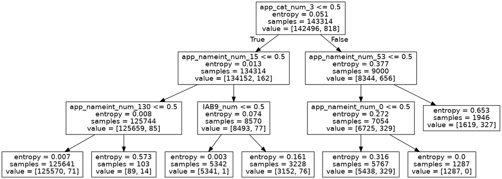

```python
Image(filename = "fig-tree.png", width=1000, height=1000)
```

```python
forest = RandomForestClassifier(criterion='entropy',
                                n_estimators=200,
                                random_state=1,
                                n_jobs=2)
forest.fit(X_train, y_train)

y_pred = forest.predict(X_test)
print('Accuracy (forest): %.2f' % accuracy_score(y_test, y_pred))
```

```
Accuracy (forest): 0.99
```

```python
importances = forest.feature_importances_
indices = np.argsort(importances)[::-1]

for f in range(X_train.shape[1]):
    print("%2d) %-*s %f" % (f + 1, 30,
                            X_features.columns.values[indices[f]],
                            importances[indices[f]]))
```

```python
from sklearn.feature_selection import SelectFromModel

sfm = SelectFromModel(forest, threshold=0.01, prefit=True)
Z_forest_alt = sfm.transform(X_features)

for f in range(Z_forest_alt.shape[1]): #mdf
    print("%2d) %-*s %f" % (f + 1, 30,
                            X_features.columns.values[indices[f]],
                            importances[indices[f]]))
```

```
 1) app_cat_num_3                  0.240015
 2) app_nameint_num_53             0.140080
 3) IAB19_num                      0.123935
 4) app_cat_num_1                  0.057053
 5) app_nameint_num_0              0.043476
 6) IAB1_num                       0.033812
 7) app_nameint_num_15             0.031890
 8) app_nameint_num_1              0.025304
 9) app_nameint_num_41             0.024073
10) app_nameint_num_26             0.020109
11) app_cat_num_0                  0.019700
12) app_nameint_num_33             0.017762
13) IAB9_num                       0.016533
14) app_nameint_num_42             0.015770
15) app_nameint_num_45             0.014685
16) app_nameint_num_7              0.012680
17) app_cat_num_2                  0.011703
18) app_nameint_num_71             0.011155
```

### Oversampling

```python
os = SMOTE(random_state=0)
X_train, X_test, y_train, y_test = train_test_split(X_features, y.astype(int), test_size=0.3, random_state=0)
columns = X_train.columns
```

```python
os_data_X,os_data_y=os.fit_sample(X_train, y_train)
os_data_X = pd.DataFrame(data=os_data_X,columns=columns )
os_data_y= pd.DataFrame(data=os_data_y,columns=['y'])
```

```python
# we can Check the numbers of our data
print("length of oversampled data is ",len(os_data_X))
print("Number of no click in oversampled data",len(os_data_y[os_data_y['y']==0]))
print("Number of click",len(os_data_y[os_data_y['y']==1]))
print("Proportion of no click data in oversampled data is ",len(os_data_y[os_data_y['y']==0])/len(os_data_X))
print("Proportion of click data in oversampled data is ",len(os_data_y[os_data_y['y']==1])/len(os_data_X))
```

```
length of oversampled data is  284992
Number of no click in oversampled data 142496
Number of click 142496
Proportion of no click data in oversampled data is  0.5
Proportion of click data in oversampled data is  0.5
```

```python
tree = DecisionTreeClassifier(criterion='entropy',
                              max_depth=3,
                              random_state=0)
tree.fit(os_data_X, os_data_y['y'])

y_pred = tree.predict(X_test)
print('Misclassified samples: %d' % (y_test != y_pred).sum())
print('Accuracy (tree): %.2f' % ((y_test == y_pred).sum() / y_test.shape[0]))
print('Accuracy (tree, sklearn): %.2f' % accuracy_score(y_test, y_pred))
```

```
Misclassified samples: 3984
Accuracy (tree): 0.94
Accuracy (tree, sklearn): 0.94
```

```python
export_graphviz(tree, out_file='tree-features-os-3.dot',
                feature_names=X.columns.values)
```

```python
tree = DecisionTreeClassifier(criterion='entropy',
                              max_depth=5,
                              random_state=0)
tree.fit(os_data_X, os_data_y['y'])

y_pred = tree.predict(X_test)
print('Misclassified samples: %d' % (y_test != y_pred).sum())
print('Accuracy (tree): %.2f' % ((y_test == y_pred).sum() / y_test.shape[0]))
print('Accuracy (tree, sklearn): %.2f' % accuracy_score(y_test, y_pred))
```

```
Misclassified samples: 4216
Accuracy (tree): 0.93
Accuracy (tree, sklearn): 0.93
```

```python
export_graphviz(tree, out_file='tree-features-os-5.dot',
                feature_names=X.columns.values)
```

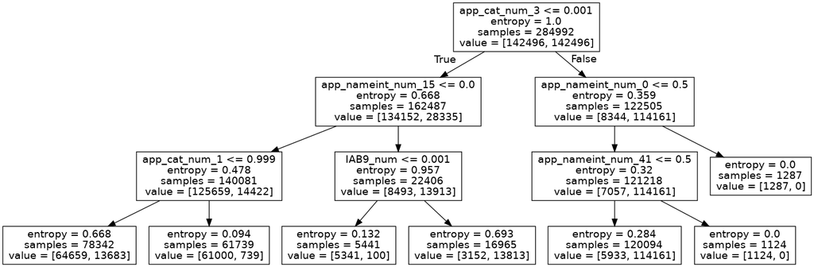

```python
Image(filename = "fig-tree-features-3.png", width=1000, height=1000)
```

```python
forest = RandomForestClassifier(criterion='entropy',
                                n_estimators=200,
                                random_state=1,
                                n_jobs=2)

forest.fit(os_data_X, os_data_y['y'])

y_pred = forest.predict(X_test)
print('Accuracy (forest): %.2f' % accuracy_score(y_test, y_pred))

importances = forest.feature_importances_
indices = np.argsort(importances)[::-1]


for f in range(X_train.shape[1]):
    print("%2d) %-*s %f" % (f + 1, 30,
                            X_features.columns.values[indices[f]],
                            importances[indices[f]]))
```

```python
result_list = []
for f in range(X_features.shape[1]):
    result_list.append(X_features.columns.values[indices[f]])
```

```python
X=os_data_X[result_list[:1]]
y=os_data_y['y']

logit_model=sm.Logit(y,X)
result=logit_model.fit()
print(result.summary2())
```

```
Optimization terminated successfully.
         Current function value: 0.502252
         Iterations 7
                          Results: Logit
==================================================================
Model:              Logit            Pseudo R-squared: 0.275
Dependent Variable: y                AIC:              286277.7052
Date:               2019-03-14 17:17 BIC:              286288.2654
No. Observations:   284992           Log-Likelihood:   -1.4314e+05
Df Model:           0                LL-Null:          -1.9754e+05
Df Residuals:       284991           LLR p-value:      nan
Converged:          1.0000           Scale:            1.0000
No. Iterations:     7.0000
-------------------------------------------------------------------
                 Coef.   Std.Err.     z      P>|z|   [0.025  0.975]
-------------------------------------------------------------------
app_cat_num_3    2.6165    0.0113  230.6077  0.0000  2.5942  2.6387
==================================================================
```

```python
X=os_data_X[result_list[:2]]
y=os_data_y['y']

logit_model=sm.Logit(y,X)
result=logit_model.fit()
print(result.summary2())
```

```
Optimization terminated successfully.
         Current function value: 0.385116
         Iterations 7
                          Results: Logit
==================================================================
Model:              Logit            Pseudo R-squared: 0.444
Dependent Variable: y                AIC:              219514.0299
Date:               2019-03-14 17:17 BIC:              219535.1503
No. Observations:   284992           Log-Likelihood:   -1.0976e+05
Df Model:           1                LL-Null:          -1.9754e+05
Df Residuals:       284990           LLR p-value:      0.0000
Converged:          1.0000           Scale:            1.0000
No. Iterations:     7.0000
------------------------------------------------------------------
                  Coef.  Std.Err.     z     P>|z|   [0.025  0.975]
------------------------------------------------------------------
app_cat_num_3     2.6177   0.0114  230.6232 0.0000  2.5955  2.6400
IAB19_num        -1.5369   0.0068 -225.2802 0.0000 -1.5503 -1.5236
==================================================================
```

- Between IAB (app_cat, IAB_xxx) and nameint variables about publisher information, regardless if data is imabalanced or not, IAB is less noisy (more predictive) than nameint.

# Predict winprice

```python
import statsmodels.formula.api as smf
```

```python
len(X_all.columns)
```

```
2399
```

```python
X = X_all
y = df['winprice']
```

```python
cols = ['Ws', 'Hs', 'bidfloor', 'age', 'hour']
X = X_all[cols]
X['min'] = df['min']
```

```python
X['gender_ord'] = pd.Categorical(df.gender).astype(str)
X['is_subscriber_ord'] = pd.Categorical(df.is_subscriber).astype(str)
X['exchange_ord'] = pd.Categorical(df.exchange).astype(str)
```

```python
X_train, X_test, y_train, y_test = train_test_split(
    X, y, test_size=0.3, random_state=0)

print('#Training data points: %d' % X_train.shape[0])
print('#Testing data points: %d' % X_test.shape[0])
print('Class labels:', np.unique(y))
```

```
#Training data points: 143314
#Testing data points: 61421
Class labels: [1.34e-07 1.00e-05 1.10e-05 ... 1.63e-03 1.64e-03 1.65e-03]
```

```python
X_train['winprice'] = y_train
```

```python
est = smf.ols(formula="winprice ~ app_bidfloor * app_Ws * app_Hs + app_exchange_ord", data=X_train).fit()
est.summary()
```

OLS Regression Results

| Dep. Variable: | winprice | R-squared: | 0.922 |
| --- | --- | --- | --- |
| Model: | OLS | Adj. R-squared: | 0.922 |
| Method: | Least Squares | F-statistic: | 2.119e+05 |
| Date: | Mon, 25 Mar 2019 | Prob (F-statistic): | 0.00 |
| Time: | 15:11:11 | Log-Likelihood: | 1.2791e+06 |
| No. Observations: | 143314 | AIC: | -2.558e+06 |
| Df Residuals: | 143305 | BIC: | -2.558e+06 |
| Df Model: | 8 |  |  |
| Covariance Type: | nonrobust |  |  |

|  | coef | std err | t | P>\|t\| | [0.025 | 0.975] |
| --- | --- | --- | --- | --- | --- | --- |
| Intercept | 8.551e-05 | 2.84e-06 | 30.102 | 0.000 | 7.99e-05 | 9.11e-05 |
| app_exchange_ord[T.smaato] | 3.499e-05 | 3.16e-07 | 110.633 | 0.000 | 3.44e-05 | 3.56e-05 |
| app_bidfloor | -0.0048 | 7.57e-05 | -63.359 | 0.000 | -0.005 | -0.005 |
| app_Ws | -3.075e-07 | 9.03e-09 | -34.072 | 0.000 | -3.25e-07 | -2.9e-07 |
| app_bidfloor:app_Ws | 1.635e-05 | 2.38e-07 | 68.748 | 0.000 | 1.59e-05 | 1.68e-05 |
| app_Hs | -4.521e-07 | 5.27e-09 | -85.746 | 0.000 | -4.62e-07 | -4.42e-07 |
| app_bidfloor:app_Hs | 9.87e-06 | 1.2e-07 | 82.206 | 0.000 | 9.64e-06 | 1.01e-05 |
| app_Ws:app_Hs | 1.662e-09 | 1.57e-11 | 105.553 | 0.000 | 1.63e-09 | 1.69e-09 |
| app_bidfloor:app_Ws:app_Hs | -2.761e-08 | 3.79e-10 | -72.797 | 0.000 | -2.84e-08 | -2.69e-08 |

| Omnibus: | 215486.461 | Durbin-Watson: | 2.002 |
| --- | --- | --- | --- |
| Prob(Omnibus): | 0.000 | Jarque-Bera (JB): | 254524948.257 |
| Skew: | 8.961 | Prob(JB): | 0.00 |
| Kurtosis: | 208.676 | Cond. No. | 8.36e+07 |

Warnings:  
[1] Standard Errors assume that the covariance matrix of the errors is correctly specified.  
[2] The condition number is large, 8.36e+07. This might indicate that there are  
strong multicollinearity or other numerical problems.

```
(-0.0009445985537353885, 0.0009445985537353885)
```

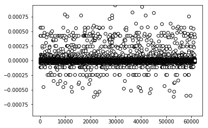

```python
resid = y_test - est.predict(X_test)
plt.scatter(range(len(resid)),resid, color='black', alpha=1.0, facecolor='white')
plt.ylim(-max(resid), max(resid))
```

- Among the individual features, the most predictive of winprice are bidfloor and creative ad size
- The best formula for predicting winprice: app_bidfloor *app_Ws* app_Hs + app_exchange_ord

# Predict bidfloor

```python
X_train, X_test, y_train, y_test = train_test_split(
    X, y, test_size=0.3, random_state=0)

print('#Training data points: %d' % X_train.shape[0])
print('#Testing data points: %d' % X_test.shape[0])
print('Class labels:', np.unique(y))
```

```python
X_train['app_bidfloor'] = y_train
```

```python
formulas = ['app_bidfloor ~ ' + col for col in X_train.columns[:-1]]
formulas
```

```python
for formula in formulas:
    print()
    print('******************************************************************************')
    print(formula)
    est = smf.ols(formula=formula, data=X_train).fit()
    print(est.summary())
```

```python
est = smf.ols(formula="bidfloor ~ Ws * Hs + exchange_ord * hour", data=X_train).fit()
est.summary()
```

OLS Regression Results

| Dep. Variable: | app_bidfloor | R-squared: | 0.646 |
| --- | --- | --- | --- |
| Model: | OLS | Adj. R-squared: | 0.646 |
| Method: | Least Squares | F-statistic: | 4.357e+04 |
| Date: | Mon, 25 Mar 2019 | Prob (F-statistic): | 0.00 |
| Time: | 16:19:19 | Log-Likelihood: | 2.0081e+05 |
| No. Observations: | 143314 | AIC: | -4.016e+05 |
| Df Residuals: | 143307 | BIC: | -4.015e+05 |
| Df Model: | 6 |  |  |
| Covariance Type: | nonrobust |  |  |

|  | coef | std err | t | P>\|t\| | [0.025 | 0.975] |
| --- | --- | --- | --- | --- | --- | --- |
| Intercept | -0.4665 | 0.004 | -114.951 | 0.000 | -0.474 | -0.459 |
| app_exchange_ord[T.smaato] | 0.0932 | 0.001 | 86.911 | 0.000 | 0.091 | 0.095 |
| app_Ws | 0.0011 | 1.25e-05 | 84.205 | 0.000 | 0.001 | 0.001 |
| app_Hs | 0.0009 | 7.07e-06 | 130.965 | 0.000 | 0.001 | 0.001 |
| app_Ws:app_Hs | -1.114e-06 | 2.08e-08 | -53.606 | 0.000 | -1.15e-06 | -1.07e-06 |
| hour | 0.0005 | 5.26e-05 | 10.014 | 0.000 | 0.000 | 0.001 |
| app_exchange_ord[T.smaato]:hour | 0.0015 | 6.82e-05 | 21.834 | 0.000 | 0.001 | 0.002 |

| Omnibus: | 96232.814 | Durbin-Watson: | 2.008 |
| --- | --- | --- | --- |
| Prob(Omnibus): | 0.000 | Jarque-Bera (JB): | 6672251.439 |
| Skew: | 2.527 | Prob(JB): | 0.00 |
| Kurtosis: | 36.043 | Cond. No. | 2.33e+06 |

Warnings:  
[1] Standard Errors assume that the covariance matrix of the errors is correctly specified.  
[2] The condition number is large, 2.33e+06. This might indicate that there are  
strong multicollinearity or other numerical problems.

- Among the individual features, the most predictive of bidfloor are creative ad size, and exchange
- The best formula for predicting bidfloor: app_Ws *app_Hs + app_exchange_ord* hour

# Predict Demographics - Gender

```python
X = X_all[(X_all.gender == '1') | (X_all.gender == '2')]
```

```python
X['gender'] = X.gender.map(lambda x: '1' if x=='1' else '0')
```

```python
y = X['gender']
exclude_cols = [col for col in X.columns if 'gender' in col]
X = X.drop(exclude_cols, axis=1) #remove cols related to gender
```

```python
y_df = pd.DataFrame(y)
```

```python
y_subs = y_df[y_df.app_userGender=='1']
```

```python
X_train, X_test, y_train, y_test = train_test_split(
    X, y.astype(int), test_size=0.3, random_state=0)

print('#Training data points: %d' % X_train.shape[0])
print('#Testing data points: %d' % X_test.shape[0])
print('Class labels:', np.unique(y))
```

```
#Training data points: 6111
#Testing data points: 2619
Class labels: ['0' '1']
```

```python
forest = RandomForestClassifier(criterion='entropy',
                                n_estimators=200,
                                random_state=1,
                                n_jobs=2)
forest.fit(X_train, y_train)
y_pred = forest.predict(X_test)
print('Accuracy (forest): %.2f' % accuracy_score(y_test, y_pred))

importances = forest.feature_importances_
indices = np.argsort(importances)[::-1]
```

```
Accuracy (forest): 0.83
```

```python
for f in range(X_train.shape[1]):
    print("%2d) %-*s %f" % (f + 1, 30,
                            X.columns.values[indices[f]],
                            importances[indices[f]]))
```

```python
result_list = []
for f in range(X_train.shape[1]):
    result_list.append(X_train.columns.values[indices[f]])
```

```python
logit_model=sm.Logit(y_train,X_train)
result=logit_model.fit()
print(result.summary2())
```

```
Optimization terminated successfully.
         Current function value: 0.664496
         Iterations 4
                             Results: Logit
========================================================================
Model:                 Logit              Pseudo R-squared:   0.016
Dependent Variable:    app_userGender     AIC:                8133.4744
Date:                  2019-03-25 18:30   BIC:                8173.7814
No. Observations:      6111               Log-Likelihood:     -4060.7
Df Model:              5                  LL-Null:            -4125.2
Df Residuals:          6105               LLR p-value:        3.8422e-26
Converged:             1.0000             Scale:              1.0000
No. Iterations:        4.0000
------------------------------------------------------------------------
                          Coef.  Std.Err.    z    P>|z|   [0.025  0.975]
------------------------------------------------------------------------
app_userAge_bucket_num_0 -0.5197   0.0553 -9.3988 0.0000 -0.6281 -0.4113
app_userAge_bucket_num_2 -0.4650   0.0594 -7.8223 0.0000 -0.5815 -0.3485
app_carrier_num_1         0.3333   0.0510  6.5329 0.0000  0.2333  0.4333
app_userAge_bucket_num_5 -0.6007   0.0601 -9.9963 0.0000 -0.7185 -0.4829
hour_bucket_num_6        -0.3270   0.0712 -4.5931 0.0000 -0.4665 -0.1875
app_bidfloor             -0.6871   0.1989 -3.4542 0.0006 -1.0770 -0.2972
========================================================================
```